# mclust 5: Clustering, Classification and Density Estimation Using Gaussian Finite Mixture Models

Luca Scrucca

Università degli Studi di Perugia

Michael Fop

University College Dublin

T. Brendan Murphy

University College Dublin

Adrian E. Raftery

University of Washington

2016-06-13

Abstract

Finite mixture models are being used increasingly to model a wide variety of random phenomena for clustering, classification and density estimation. *mclust* is a powerful and popular package which allows modelling of data as a Gaussian finite mixture with different covariance structures and different numbers of mixture components, for a variety of purposes of analysis. Recently, version 5 of the package has been made available on CRAN. This updated version adds new covariance structures, dimension reduction capabilities for visualisation, model selection criteria, initialisation strategies for the EM algorithm, and bootstrap-based inference, making it a full-featured R package for data analysis via finite mixture modelling.

# Introduction

[*mclust*](https://CRAN.R-project.org/package=mclust) (Fraley, Raftery, and Scrucca 2016) is a popular R package for model-based clustering, classification, and density estimation based on finite Gaussian mixture modelling. An integrated approach to finite mixture models is provided, with functions that combine model-based hierarchical clustering, EM for mixture estimation and several tools for model selection. Thus *mclust* provides a comprehensive strategy for clustering, density estimation and discriminant analysis. A variety of covariance structures obtained through eigenvalue decomposition are available. Functions for performing single E and M steps and for simulating data for each available model are also included. Additional ways of displaying and visualising fitted models along with clustering, classification, and density estimation results are also provided. It has been used in a broad range of contexts including geochemistry (Templ, Filzmoser, and Reimann 2008; Ellefsen, Smith, and Horton 2014), chemometrics (Fraley and Raftery 2006b, 2007b), DNA sequence analysis (Verbist et al. 2015), gene expression data (Yeung et al. 2001; Li et al. 2005; Fraley and Raftery 2006a), hydrology (Kim et al. 2014), wind energy (Kazor and Hering 2015), industrial engineering (Campbell et al. 1999), epidemiology (Flynt and Daepp 2015), food science (Kozak and Scaman 2008), clinical psychology (Suveg et al. 2014), political science (Ahlquist and Breunig 2012; Jang and Hitchcock 2012), and anthropology (Konigsberg, Algee-Hewitt, and Steadman 2009).

One measure of the popularity of *mclust* is provided by the download logs of the RStudio (http://www.rstudio.com) CRAN mirror (available at http://cran-logs.rstudio.com). The [*cranlogs*](https://CRAN.R-project.org/package=cranlogs) package (Csardi 2015) makes it easy to download such logs and graph the number of downloads over time. We used *cranlogs* to query the RStudio download database over the past three years. In addition to *mclust*, other R packages which handle Gaussian finite mixture modelling as part of their capabilities have been included in the comparison: [*Rmixmod*](https://CRAN.R-project.org/package=Rmixmod) (Lebret et al. 2015), [*mixture*](https://CRAN.R-project.org/package=mixture) (Ryan P. Browne, ElSherbiny, and McNicholas 2015), [*EMCluster*](https://CRAN.R-project.org/package=EMCluster) (Chen and Maitra 2015), [*mixtools*](https://CRAN.R-project.org/package=mixtools) (Benaglia et al. 2009), and [*bgmm*](https://CRAN.R-project.org/package=bgmm) (Biecek et al. 2012). We also included [*flexmix*](https://CRAN.R-project.org/package=flexmix) (Leisch 2004; Grün and Leisch 2007, 2008) which provides a general framework for finite mixtures of regression models using the EM algorithm, since it can be adapted to perform Gaussian model-based clustering using a limited set of models (only the diagonal and unconstrained covariance matrix models). Table 1 summarises the functionalities of the selected packages.

Table 1: Capabilities of the selected packages dealing with finite mixture models.

| Package | Version | Clustering | Classification | Density estimation | Non-Gaussian components |
| --- | --- | --- | --- | --- | --- |
| *mclust* | 5.2 | $✓$ | $✓$ | $✓$ | $✗$ |
| *Rmixmod* | 2.0.3 | $✓$ | $✓$ | $✗$ | $✓$ |
| *mixture* | 1.4 | $✓$ | $✓$ | $✗$ | $✗$ |
| *EMCluster* | 0.2-5 | $✓$ | $✓$ | $✗$ | $✗$ |
| *mixtools* | 1.0.4 | $✓$ | $✗$ | $✓$ | $✓$ |
| *bgmm* | 1.7 | $✓$ | $✓$ | $✗$ | $✗$ |
| *flexmix* | 2.3-13 | $✓$ | $✗$ | $✗$ | $✓$ |

Figure 1 shows the trend in weekly downloads from the RStudio CRAN mirror for the selected packages. The popularity of *mclust* has been increasing steadily over time with a first high peak around mid April 2015, probably due to the release of R version 3.2 and, shortly after, the release of version 5 of *mclust*. Then, successive peaks occurred in conjunction with the release of package’s updates. Based on these logs, *mclust* is the most downloaded package dealing with Gaussian mixture models, followed by *flexmix* which, as mentioned, is a more general package for fitting mixture models but with limited clustering capabilities.

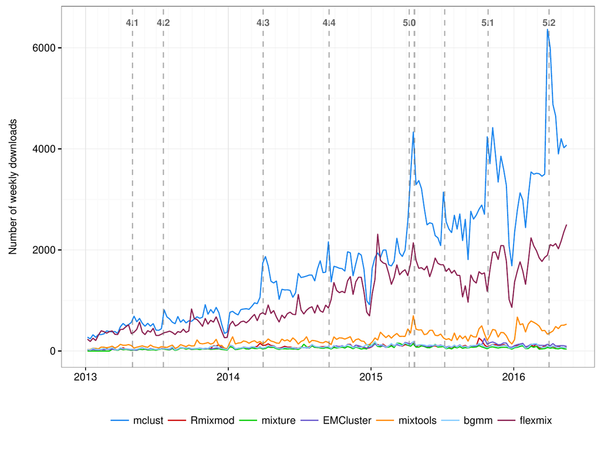

Figure 1: Number of weekly downloads from the RStudio CRAN mirror over time for some R packages dealing with Gaussian finite mixture modelling.

Another aspect that can be considered as a proxy for the popularity of a package is the mutual dependencies structure between R packages[^1]. This can be represented as a graph with packages at the vertices and dependencies (either “Depends”, “Imports”, “LinkingTo”, “Suggests” or “Enhances”) as directed edges, and analysed through the *PageRank* algorithm used by the Google search engine (Brin and Page 1998). For the packages considered previously, we used the `page.rank` function available in the [*igraph*](https://CRAN.R-project.org/package=igraph) package (Csardi and Nepusz 2006) and we obtained the ranking reported in Table 2, which approximately reproduces the results discussed above. Note that *mclust* is among the top 100 packages on CRAN by this ranking. Finally, its popularity is also indicated by the 55 other CRAN packages listed as reverse dependencies, either “Depends”, “Imports” or “Suggests”.

Table 2: Ranking obtained with the *PageRank* algorithm for some R packages dealing with Gaussian finite mixture modelling. At the time of writing there are 8663 packages on CRAN.

| *mclust* | *Rmixmod* | *mixture* | *EMCluster* | *mixtools* | *bgmm* | *flexmix* |
| --- | --- | --- | --- | --- | --- | --- |
| 75 | 2300 | 2319 | 2143 | 1698 | 3736 | 270 |

Earlier versions of the package have been described in Fraley and Raftery (1999), Fraley and Raftery (2003), and Fraley et al. (2012). In this paper we discuss some of the new functionalities available in *mclust* version $\ge 5$. In particular we describe the newly available models, dimension reduction for visualisation, bootstrap-based inference, implementation of different model selection criteria and initialisation strategies for the EM algorithm.

The reader should first install the latest version of the package from CRAN with

```r
> install.packages("mclust")
```

Then the package is loaded into an R session using the command

```r
> library(mclust)
    __  ___________    __  _____________
   /  |/  / ____/ /   / / / / ___/_  __/
  / /|_/ / /   / /   / / / /\__ \ / /
 / /  / / /___/ /___/ /_/ /___/ // /
/_/  /_/\____/_____/\____//____//_/    version 5.2
Type 'citation("mclust")' for citing this R package in publications.
```

All the datasets used in the examples are available in *mclust* or in other R packages, such as [*gclus*](https://CRAN.R-project.org/package=gclus) (Hurley 2012), [*rrcov*](https://CRAN.R-project.org/package=rrcov) (Todorov and Filzmoser 2009) and [*tourr*](https://CRAN.R-project.org/package=tourr) (Wickham et al. 2011), and can be installed from CRAN using the above procedure, except where noted differently.

# Gaussian finite mixture modelling

Let $\mathbf{x}= \lbrace \mathbf{x}_1,\mathbf{x}_2,\ldots,\mathbf{x}_i,\ldots,\mathbf{x}_n \rbrace$ be a sample of $n$ independent identically distributed observations. The distribution of every observation is specified by a probability density function through a finite mixture model of $G$ components, which takes the following form
$$f(\mathbf{x}_i; \mathbf{\Psi}) = \sum_{k=1}^G
\pi_k f_k(\mathbf{x}_i; \mathbf{\theta}_k),
\label{eq:finmixdens} (\#eq:eqfinmixdens)$$
where $\mathbf{\Psi}= \{\pi_1, \ldots, \pi_{G-1}, \mathbf{\theta}_1, \ldots, \mathbf{\theta}_G\}$ are the parameters of the mixture model, $f_k(\mathbf{x}_i; \mathbf{\theta}_k)$ is the $k$th component density for observation $\mathbf{x}_i$ with parameter vector $\mathbf{\theta}_k$, $(\pi_1,\ldots,\pi_{G-1})$ are the mixing weights or probabilities (such that $\pi_k > 0$, $\sum_{k=1}^G\pi_k = 1$), and $G$ is the number of mixture components.

Assuming that $G$ is fixed, the mixture model parameters $\mathbf{\Psi}$ are usually unknown and must be estimated. The log-likelihood function corresponding to equation @ref(eq:eqfinmixdens) is given by $\ell(\mathbf{\Psi}; \mathbf{x}_1, \ldots, \mathbf{x}_n) = \sum_{i=1}^{n} \log(f(\mathbf{x}_i; \mathbf{\Psi}))$. Direct maximisation of the log-likelihood function is complicated, so the maximum likelihood estimator (MLE) of a finite mixture model is usually obtained via the EM algorithm (Dempster, Laird, and Rubin 1977; G. J. McLachlan and Peel 2000).

In the model-based approach to clustering, each component of a finite mixture density is usually associated with a group or cluster. Most applications assume that all component densities arise from the same parametric distribution family, although this need not be the case in general. A popular model is the Gaussian mixture model (GMM), which assumes a (multivariate) Gaussian distribution for each component, i.e. $f_k(\mathbf{x}; \mathbf{\theta}_k) \sim N(\mathbf{\mu}_k, \mathbf{\Sigma}_k)$. Thus, clusters are ellipsoidal, centered at the mean vector $\mathbf{\mu}_k$, and with other geometric features, such as volume, shape and orientation, determined by the covariance matrix $\mathbf{\Sigma}_k$. Parsimonious parameterisations of the covariances matrices can be obtained by means of an eigen-decomposition of the form $\mathbf{\Sigma}_k = \lambda_k \mathbf{D}_k \mathbf{A}_k \mathbf{D}{}^{\!\top}_k$, where $\lambda_k$ is a scalar controlling the volume of the ellipsoid, $\mathbf{A}_k$ is a diagonal matrix specifying the shape of the density contours with $\det(\mathbf{A}_k)=1$, and $\mathbf{D}_k$ is an orthogonal matrix which determines the orientation of the corresponding ellipsoid (Banfield and Raftery 1993; Celeux and Govaert 1995). In one dimension, there are just two models: `E` for equal variance and `V` for varying variance. In the multivariate setting, the volume, shape, and orientation of the covariances can be constrained to be equal or variable across groups. Thus, 14 possible models with different geometric characteristics can be specified. Table 3 reports all such models with the corresponding distribution structure type, volume, shape, orientation, and associated model names. In Figure 2 the geometric characteristics are shown graphically.

Table 3: Parameterisations of the within-group covariance matrix $\mathbf{\Sigma}_k$ for multidimensional data available in the *mclust* package, and the corresponding geometric characteristics.

| Model | $\mathbf{\Sigma}_k$ | Distribution | Volume | Shape | Orientation |
| --- | --- | --- | --- | --- | --- |
| `EII` | $\lambda \mathbf{I}$ | Spherical | Equal | Equal | — |
| `VII` | $\lambda_k \mathbf{I}$ | Spherical | Variable | Equal | — |
| `EEI` | $\lambda \mathbf{A}$ | Diagonal | Equal | Equal | Coordinate axes |
| `VEI` | $\lambda_k \mathbf{A}$ | Diagonal | Variable | Equal | Coordinate axes |
| `EVI` | $\lambda \mathbf{A}_k$ | Diagonal | Equal | Variable | Coordinate axes |
| `VVI` | $\lambda_k \mathbf{A}_k$ | Diagonal | Variable | Variable | Coordinate axes |
| `EEE` | $\lambda \mathbf{D}\mathbf{A}\mathbf{D}{}^{\!\top}$ | Ellipsoidal | Equal | Equal | Equal |
| `EVE` | $\lambda \mathbf{D}\mathbf{A}_k \mathbf{D}{}^{\!\top}$ | Ellipsoidal | Equal | Variable | Equal |
| `VEE` | $\lambda_k \mathbf{D}\mathbf{A}\mathbf{D}{}^{\!\top}$ | Ellipsoidal | Variable | Equal | Equal |
| `VVE` | $\lambda_k \mathbf{D}\mathbf{A}_k \mathbf{D}{}^{\!\top}$ | Ellipsoidal | Variable | Variable | Equal |
| `EEV` | $\lambda \mathbf{D}_k \mathbf{A}\mathbf{D}{}^{\!\top}_k$ | Ellipsoidal | Equal | Equal | Variable |
| `VEV` | $\lambda_k \mathbf{D}_k \mathbf{A}\mathbf{D}{}^{\!\top}_k$ | Ellipsoidal | Variable | Equal | Variable |
| `EVV` | $\lambda \mathbf{D}_k \mathbf{A}_k \mathbf{D}{}^{\!\top}_k$ | Ellipsoidal | Equal | Variable | Variable |
| `VVV` | $\lambda_k \mathbf{D}_k \mathbf{A}_k \mathbf{D}{}^{\!\top}_k$ | Ellipsoidal | Variable | Variable | Variable |

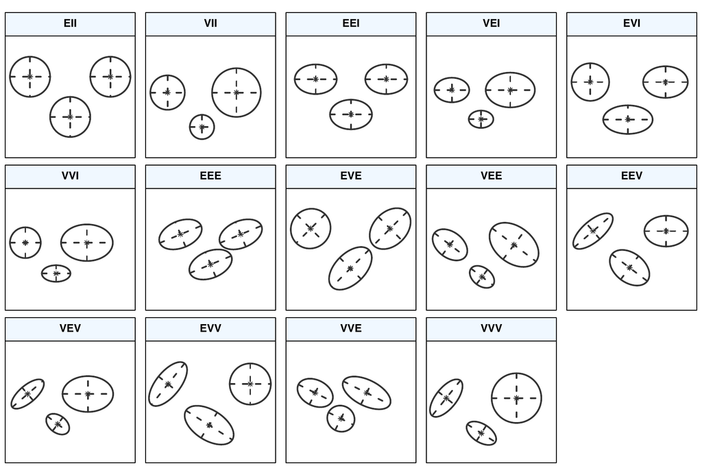

Figure 2: Ellipses of isodensity for each of the 14 Gaussian models obtained by eigen-decomposition in case of three groups in two dimensions.

Starting with version $5.0$ of *mclust*, four additional models have been included: EVV, VEE, EVE, VVE. Models EVV and VEE are estimated using the methods described in Celeux and Govaert (1995), and the estimation of models EVE and VVE is carried out using the approach discussed by Ryan P. Browne and McNicholas (2014). In the models VEE, EVE and VVE it is assumed that the mixture components share the same orientation matrix. This assumption allows for a parsimonious characterisation of the clusters, while still retaining flexibility in defining volume and shape.

# Model-based clustering

To illustrate the new modelling capabilities of *mclust* for model-based clustering consider the `wine` dataset contained in the *gclus* R package. This dataset provides 13 measurements obtained from a chemical analysis of 178 wines grown in the same region in Italy but derived from three different cultivars (Barolo, Grignolino, Barbera).

```r
> data(wine, package = "gclus")
> Class <- factor(wine$Class, levels = 1:3,
                  labels = c("Barolo", "Grignolino", "Barbera"))
> X <- data.matrix(wine[,-1])
> mod <- Mclust(X)
> summary(mod$BIC)
Best BIC values:
             EVE,3       VVE,3       VVE,6
BIC      -6873.257 -6896.83693 -6906.37460
BIC diff     0.000   -23.57947   -33.11714
> plot(mod, what = "BIC", ylim = range(mod$BIC[,-(1:2)], na.rm = TRUE),
       legendArgs = list(x = "bottomleft"))
```

In the above `Mclust()` function call, only the data matrix is provided, and the number of mixing components and the covariance parameterisation are selected using the Bayesian Information Criterion (BIC). A summary showing the top-three models and a plot of the BIC traces (see Figure 3) for all the models considered is then obtained. In the last plot we adjusted the range of the y-axis so to remove those models with lower BIC values. There is a clear indication of a three-component mixture with covariances having different shapes but the same volume and orientation (EVE). Note that all the top three models are among the models added to the latest major release of *mclust*.

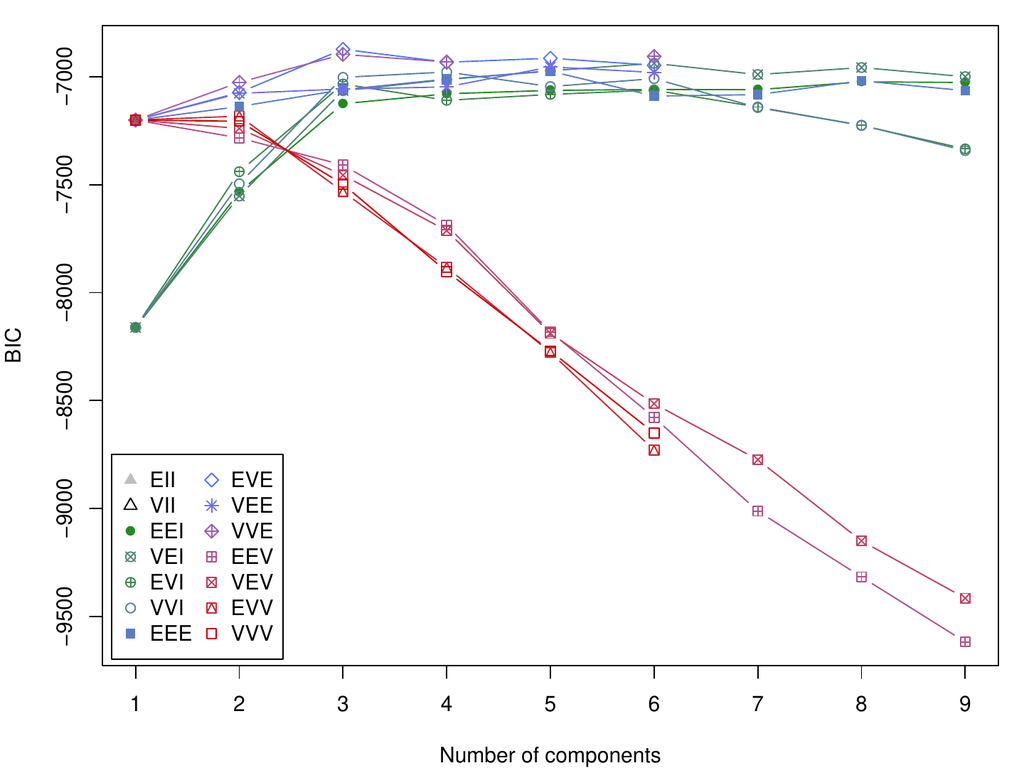

Figure 3: BIC plot for models fitted to the `wine` data.

A summary of the selected model is obtained as:

```r
> summary(mod)
----------------------------------------------------
Gaussian finite mixture model fitted by EM algorithm
----------------------------------------------------

Mclust EVE (ellipsoidal, equal volume and orientation) model with 3 components:

 log.likelihood   n  df       BIC       ICL
       -3032.45 178 156 -6873.257 -6873.549

Clustering table:
 1  2  3
63 51 64
```

The fitted model provides an accurate recovery of the true classes:

```r
> table(Class, mod$classification)
Class         1  2  3
  Barolo     59  0  0
  Grignolino  4  3 64
  Barbera     0 48  0
> adjustedRandIndex(Class, mod$classification)
[1] 0.8803998
```

The latter index is the adjusted Rand index [ARI; Hubert and Arabie (1985)], which can be used for evaluating a clustering solution. The ARI is a measure of agreement between two partitions, one estimated by a statistical procedure independent of the labelling of the groups, and one being the true classification. It has zero expected value in the case of a random partition, and it is bounded above by 1, with higher values representing better partition accuracy.

To visualise the clustering structure and the geometric characteristics induced by an estimated Gaussian finite mixture model we may project the data onto a suitable dimension reduction subspace. The function `MclustDR()` implements the methodology introduced in Luca Scrucca (2010). The estimated directions which span the reduced subspace are defined as a set of linear combinations of the original features, ordered by importance as quantified by the associated eigenvalues. By default, information on the dimension reduction subspace is provided by both the variation on cluster means and, depending on the estimated mixture model, on the variation on cluster covariances. This methodology has been extended to supervised classification by Luca Scrucca (2014). Furthermore, a tuning parameter has been included which enables the recovery of most of the separating directions, i.e. those that show maximal separation among groups. Other dimension reduction techniques for finding the directions of optimum separation have been discussed in detail by Hennig (2004) and implemented in the package [*fpc*](https://CRAN.R-project.org/package=fpc) (Hennig 2015).

Applying `MclustDR` to the wine data example, such directions are obtained as follows:

```r
> drmod <- MclustDR(mod, lambda = 1)
> summary(drmod)
-----------------------------------------------------------------
Dimension reduction for model-based clustering and classification
-----------------------------------------------------------------

Mixture model type: Mclust (EVE, 3)

Clusters  n
       1 63
       2 51
       3 64

Estimated basis vectors:
                       Dir1       Dir2
Alcohol          0.11701058  0.2637302
Malic           -0.02814821  0.0489447
Ash             -0.18258917  0.5390056
Alcalinity      -0.02969793 -0.0309028
Magnesium        0.00575692  0.0122642
Phenols         -0.18497201 -0.0016806
Flavanoids       0.45479873 -0.2948947
Nonflavanoid     0.59278569 -0.5777586
Proanthocyanins  0.05347167  0.0508966
Intensity       -0.08328239  0.0332611
Hue              0.42950365 -0.4588969
OD280            0.40563746 -0.0369229
Proline          0.00075867  0.0010457

               Dir1    Dir2
Eigenvalues  1.5794   1.332
Cum. %      54.2499 100.000
```

By setting the optional tuning parameter `lambda = 1`, instead of the default value `0.5`, only the information on cluster means is used for estimating the directions. In this case, the dimension of the subspace is $d = \min(p, G-1)$, where $p$ is the number of variables and $G$ the number of mixture components or clusters. In the data example, there are $p=13$ features and $G=3$ clusters, so the dimension of the reduced subspace is $d=2$. As a result, the projected data show the maximal separation among clusters, as shown in Figure 4a, which is obtained with

```r
> plot(drmod, what = "contour")
```

On the same subspace we can also plot the uncertainty boundaries corresponding to the MAP classification:

```r
> plot(drmod, what = "boundaries", ngrid = 200)
```

and then add a circle around the misclassified observations

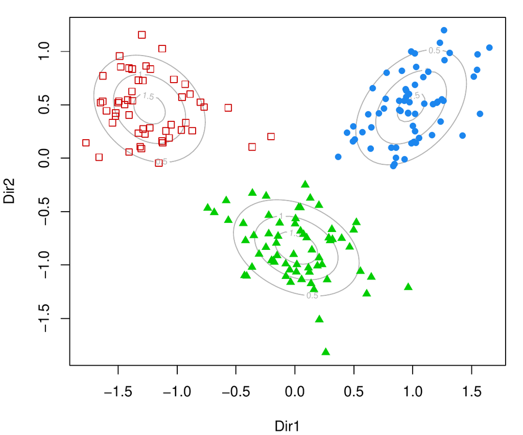

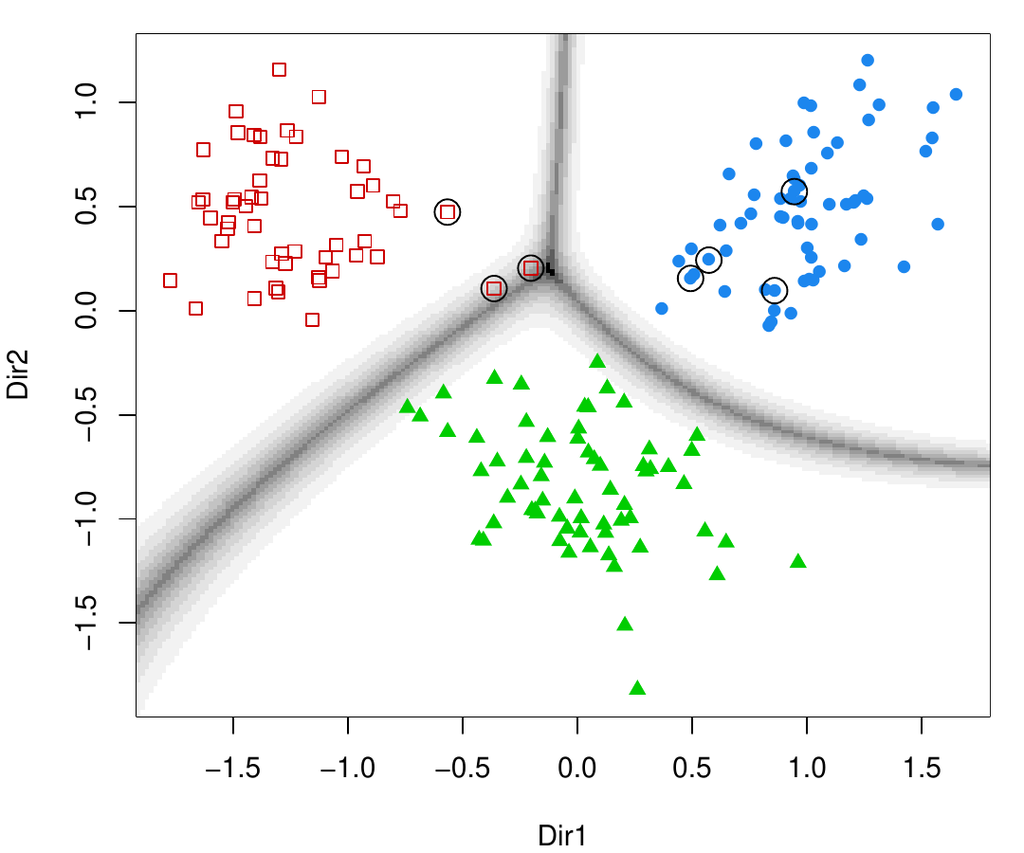

```r
> miscl <- classError(Class, mod$classification)$misclassified
> points(drmod$dir[miscl,], pch = 1, cex = 2)
```

(a)

(b)

Figure 4: Contour plot of estimated mixture densities (a) and uncertainty boundaries (b) on the projection subspace estimated with `MclustDR` for the `wine` dataset.

# Model selection

A central question in finite mixture modelling is how many components should be included in the mixture. In GMMs we need also to decide which covariance parameterisation to adopt. Both questions can be addressed by information criteria, such as the BIC (Schwartz 1978; Fraley and Raftery 1998) or the integrated complete-data likelihood criterion [ICL; Biernacki, Celeux, and Govaert (2000)]. The selection of the order of the mixture, i.e. the number of mixture components or clusters, can be also performed by formal hypothesis testing; for a recent review see Geoffrey J. McLachlan and Rathnayake (2014).

Information criteria are based on penalised forms of the log-likelihood. As the likelihood increases with the addition of more components, a penalty term for the number of estimated parameters is subtracted from the log-likelihood. The BIC is a popular choice in the context of GMMs, and takes the form
$$\mathrm{BIC}_{\mathcal{M}, G} =
2\ell_{\mathcal{M}, G}(\mathbf{x}|\widehat{\mathbf{\Psi}}) - \nu
\log(n),$$
where $\ell_{\mathcal{M}, G}(\mathbf{x}|\widehat{\mathbf{\Psi}})$ is the log-likelihood at the MLE $\widehat{\mathbf{\Psi}}$ for model $\mathcal{M}$ with $G$ components, $n$ is the sample size, and $\nu$ is the number of estimated parameters. The pair $\{\mathcal{M},G\}$ which maximises $\mathrm{BIC}_{\mathcal{M}, G}$ is selected. Given some necessary regularity conditions, BIC is derived as an approximation to the model evidence using the Laplace method. Although these conditions do not hold for mixture models in general (Aitkin and Rubin 1985), some consistency results apply (Roeder and Wasserman 1997; Keribin 2000) and the criterion has been shown to perform well in applications (Fraley and Raftery 1998).

In the *mclust* package, BIC is used by default for model selection. The function `mclustBIC()` allows the user to obtain a matrix of BIC values for all the available models and number of components up to 9 (by default).

For example, consider the `diabetes` dataset which contains measurements on 145 non-obese adult subjects. Recorded variables are `glucose`, the area under plasma glucose curve after a three hour oral glucose tolerance test (OGTT), `insulin`, the area under plasma insulin curve after a three hour OGTT, and `sspg`, the steady state plasma glucose level. The patients are classified clinically into three groups.

```r
> data(diabetes)
> X <- diabetes[,2:4]
> Class <- diabetes$class
> table(Class)
Chemical   Normal    Overt
      36       76       33
```

The data can be shown graphically (see Figure 5) as follows:

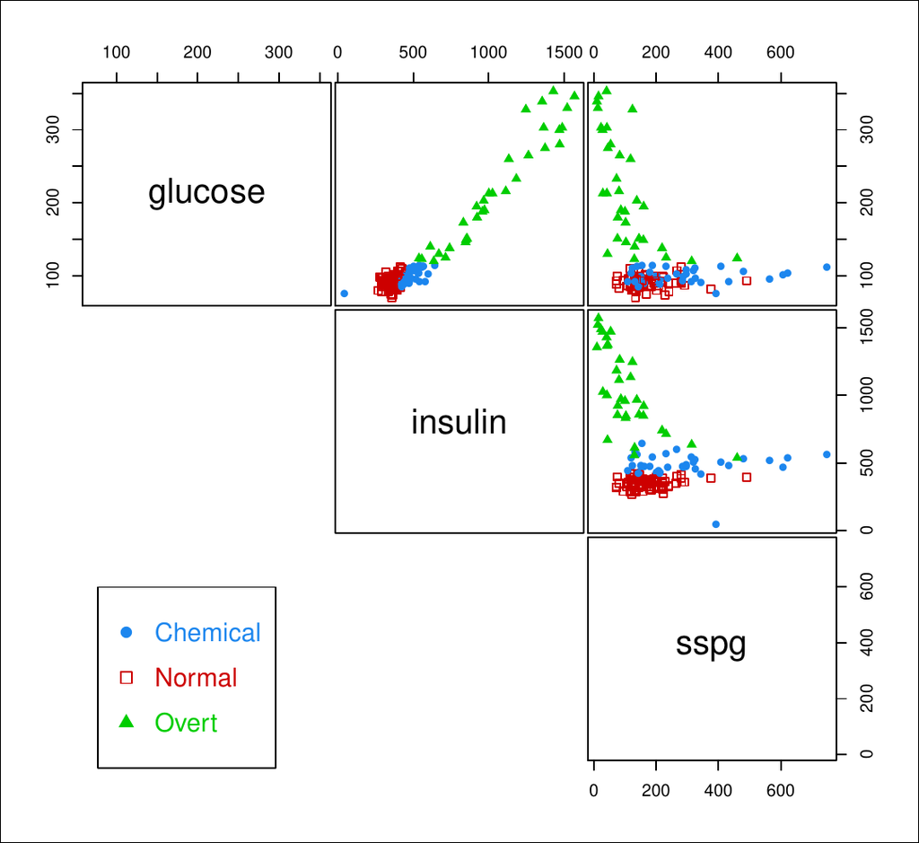

Figure 5: Pairwise scatterplots for the `diabetes` data with points marked according to classification.

```r
> clp <- clPairs(X, Class, lower.panel = NULL)
> clPairsLegend(0.1, 0.3, class = clp$class, col = clp$col, pch = clp$pch)
```

The following function call can be used to compute the BIC for all the covariance structures and up to 9 components:

```r
> BIC <- mclustBIC(X)
> BIC
Bayesian Information Criterion (BIC):
        EII       VII       EEI       VEI       EVI       VVI       EEE       EVE
1 -5863.923 -5863.923 -5530.129 -5530.129 -5530.129 -5530.129 -5136.446 -5136.446
2 -5449.518 -5327.719 -5169.399 -5019.350 -5015.884 -4988.322 -5010.994 -4875.633
3 -5412.588 -5206.399 -4998.446 -4899.759 -5000.661 -4827.818 -4976.853 -4858.851
4 -5236.008 -5208.512 -4937.627 -4835.856 -4865.767 -4813.002 -4865.864 -4793.261
5 -5181.608 -5202.555 -4915.486 -4841.773 -4838.587 -4833.589 -4882.812        NA
6 -5162.164 -5135.069 -4885.752        NA -4848.623 -4810.558 -4835.226        NA
7 -5128.736 -5129.460 -4857.097        NA -4849.023        NA -4805.518        NA
8 -5135.787 -5135.053 -4858.904        NA -4873.450        NA -4820.155        NA
9 -5150.374 -5112.616 -4878.786        NA -4865.166        NA -4840.039        NA
        VEE       VVE       EEV       VEV       EVV       VVV
1 -5136.446 -5136.446 -5136.446 -5136.446 -5136.446 -5136.446
2 -4920.301 -4877.086 -4918.500 -4834.727 -4823.779 -4825.027
3 -4851.667 -4775.537 -4917.567 -4809.225 -4817.884 -4760.091
4 -4840.034 -4794.892 -4887.406 -4823.882 -4828.796 -4802.420
5        NA        NA -4908.030 -4842.077        NA        NA
6        NA        NA -4844.584 -4826.457        NA        NA
7        NA        NA -4910.155 -4852.182        NA        NA
8        NA        NA -4858.974 -4870.633        NA        NA
9        NA        NA -4930.535 -4887.206        NA        NA

Top 3 models based on the BIC criterion:
    VVV,3     VVE,3     EVE,4
-4760.091 -4775.537 -4793.261
```

In the results reported above, the `NA` values mean that a particular model cannot be estimated. This happens in practice due to singularity in the covariance matrix estimate and can be avoided using the Bayesian regularisation proposed in Fraley and Raftery (2007a) and implemented in *mclust* as described in Fraley et al. (2012). Optional arguments allow finetuning, such as `G` for the number of components, and `modelNames` for specifying the model covariances parameterisations (see Table 3 and `help(mclustModelNames)` for a description of available model names). Another optional argument `x` can be used to provide the output from a previous call to `mclustBIC()`. This is useful if the model space needs to be enlarged by fitting more models, e.g. by increasing the number of mixture components, without the need to recompute the BIC values for those models already fitted. Another usage of such strategy that may be helpful to users is provided in `Mclust()`. For example, BIC values already available can be provided as follows

```r
> Mclust(X, x = BIC)
```

Note that by specifying the argument `G` and `modelNames` the model space can be restricted to a subset, or enlarged to a superset. In the latter case the BIC is calculated only for the newly included models.

The use of BIC for model selection was available in *mclust* since earlier versions. However, BIC tends to select the number of mixture components needed to reasonably approximate the density, rather than the number of clusters as such. For this reason, other criteria have been proposed for model selection, like the *integrated complete-data likelihood* (ICL) criterion (Biernacki, Celeux, and Govaert 2000):
$$\mathrm{ICL}_{\mathcal{M}, G} =
\mathrm{BIC}_{\mathcal{M}, G} + 2 \sum_{i=1}^n\sum_{k=1}^G
c_{ik}\log(z_{ik}),$$
where $z_{ik}$ is the conditional probability that $\mathbf{x}_i$ arises from the $k$th mixture component, and $c_{ik} = 1$ if the $i$th unit is assigned to cluster $k$ and 0 otherwise. ICL penalises the BIC through an *entropy* term which measures clusters overlap. Provided that clusters overlapping is not too strong, ICL has shown good performance in selecting the number of clusters, with preference for solutions with well-separated groups.

In *mclust* the ICL can be computed by means of the `mclustICL()` function:

```r
> ICL <- mclustICL(X)
> ICL
Integrated Complete-data Likelihood (ICL) criterion:
        EII       VII       EEI       VEI       EVI       VVI       EEE       EVE
1 -5863.923 -5863.923 -5530.129 -5530.129 -5530.129 -5530.129 -5136.446 -5136.446
2 -5450.004 -5333.689 -5169.732 -5023.533 -5016.010 -4994.986 -5012.758 -4876.295
3 -5415.983 -5219.627 -4999.693 -4910.963 -5011.423 -4839.130 -4985.448 -4875.992
4 -5238.797 -5224.698 -4939.741 -4847.524 -4876.784 -4823.308 -4867.650 -4809.169
5 -5190.524 -5226.204 -4923.986 -4865.230 -4854.347 -4859.162 -4895.412        NA
6 -5171.561 -5158.411 -4901.823        NA -4865.106 -4820.076 -4846.827        NA
7 -5136.220 -5152.330 -4872.644        NA -4870.151        NA -4817.584        NA
8 -5146.628 -5156.135 -4871.975        NA -4897.172        NA -4834.074        NA
9 -5180.744 -5145.708 -4911.346        NA -4883.199        NA -4872.677        NA
        VEE       VVE       EEV       VEV       EVV       VVV
1 -5136.446 -5136.446 -5136.446 -5136.446 -5136.446 -5136.446
2 -4927.621 -4885.421 -4920.413 -4844.590 -4826.796 -4834.539
3 -4866.976 -4793.271 -4927.563 -4821.068 -4828.535 -4776.086
4 -4869.658 -4823.020 -4956.077 -4847.034 -4839.703 -4830.658
5        NA        NA -4948.787 -4869.279        NA        NA
6        NA        NA -4884.720 -4849.505        NA        NA
7        NA        NA -4947.190 -4878.445        NA        NA
8        NA        NA -4890.913 -4895.286        NA        NA
9        NA        NA -5007.250 -4919.228        NA        NA

Top 3 models based on the ICL criterion:
    VVV,3     VVE,3     EVE,4
-4776.086 -4793.271 -4809.169
```

As discussed above for `mclustBIC()`, the output from a previous call to `mclustICL()` can be provided as input with the argument `x` to avoid recomputing the ICL for models already fitted.

Both criteria can be shown graphically with (see Figure 6):

```r
> plot(BIC)
> plot(ICL)
```

In this case BIC and ICL selected the same final model.

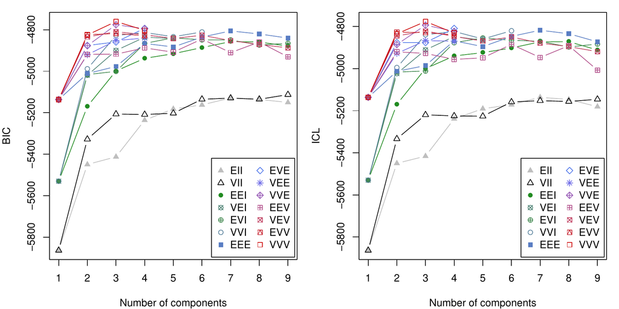

Figure 6: Plots of BIC and ICL model selection criteria for the `diabetes` data.

Other information criteria are available in the literature. For example, members of the Generalised Information Criteria (GIC) family (Konishi and Kitagawa 1996) are not computed by the package, but they can be easily obtained using the information returned by the `Mclust()` function.

In addition to the information criteria just mentioned, the choice of the order of a mixture model for a specific component-covariances parameterisation can be carried out by likelihood ratio testing (LRT). Suppose we want to test the null hypothesis $H_0: G = G_0$ against the alternative $H_1: G = G_1$ for some $G_1 > G_0$; usually, $G_1 = G_0 + 1$ as it is a common procedure to keep adding components sequentially. Let $\widehat{\mathbf{\Psi}}_{G_j}$ be the MLE of $\mathbf{\Psi}$ calculated under $H_j: G = G_j$ (for $j = 0,1$). The likelihood ratio test statistic (LRTS) can be written as
$$\mathrm{LRTS}=
-2\log\{L(\widehat{\mathbf{\Psi}}_{G_0})/L(\widehat{\mathbf{\Psi}}_{G_1})\}
= 2\{ \ell(\widehat{\mathbf{\Psi}}_{G_1}) -
\ell(\widehat{\mathbf{\Psi}}_{G_0}) \},$$
where large values of LRTS provide evidence against the null hypothesis. However, standard regularity conditions do not hold for the null distribution of the LRTS to have its usual chi-squared distribution (G. J. McLachlan and Peel 2000, chap. 6). As consequence, LRT significance is often estimated by a resampling approach in order to produce a $p$-value. Geoffrey J. McLachlan (1987) proposed the using of the bootstrap to obtain the null distribution of the LRTS. The bootstrap procedure is the following:

1. a bootstrap sample $\mathbf{x}_b^*$ is generated by simulating from the fitted model under the null hypothesis with $G_0$ components, i.e. from the GMM distribution with the vector of unknown parameters replaced by MLEs obtained from the original data under $H_0$;
2. the test statistic $\mathrm{LRTS}^*_b$ is computed for the bootstrap sample $\mathbf{x}_b^*$ after fitting GMMs with $G_0$ and $G_1$ number of components;
3. steps 1. and 2. are replicated several times, say $B = 999$, to obtain the bootstrap null distribution of $\mathrm{LRTS}^*$.

A bootstrap-based approximation to the $p$-value may then be computed as
$$p\text{-value} \approx \frac{1 + \sum_{i=1}^B
\mathrm{I}(\mathrm{LRTS}^*_b \ge \mathrm{LRTS}_{obs})}{B+1}$$
where $\mathrm{LRTS}_{obs}$ is the test statistic computed on the observed sample $\mathbf{x}$, and $\mathrm{I}(\cdot)$ denotes the indicator function (which is equal to 1 if its argument is true and 0 otherwise).

The above bootstrap procedure is implemented in the `mclustBootstrapLRT()` function. We need to specify at least the input data and the model name we want to test:

```r
> LRT <- mclustBootstrapLRT(X, modelName = "VVV")
> LRT
Bootstrap sequential LRT for the number of mixture components
-------------------------------------------------------------
Model        = VVV
Replications = 999
               LRTS bootstrap p-value
1 vs 2   361.186445             0.001
2 vs 3   114.703559             0.001
3 vs 4     7.437806             0.938
```

The number of bootstrap resamples can be set by the optional argument `nboot`; if not provided, `nboot = 999` is used. The sequential bootstrap procedure terminates when a test is not significant at the level specified by `level` (by default equal to `0.05`). There is also the option for a user to fix the maximum number of mixture components to test via the argument `maxG`. In the example above the bootstrap $p$-values clearly indicate the presence of three clusters. Note that models fitted on the original data are estimated via the EM algorithm initialised by the default model-based hierarchical agglomerative clustering. Then, during the bootstrap procedure, models under the null and the alternative hypotheses are fitted on bootstrap samples using again the EM algorithm. However, in this case the algorithm starts with the E step initialised with the estimated parameters obtained at the convergence of the EM algorithm on the original data.

The bootstrap distributions of the LRTS can be shown graphically (see Figure 7) using the associated plot method:

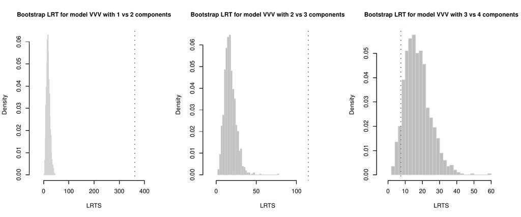

Figure 7: Histograms of LRTS bootstrap distributions for testing the number of mixture components in the `diabetes` data. The dotted vertical lines refer to the sample values of LRTS.

```r
> plot(LRT, G = 1)
> plot(LRT, G = 2)
> plot(LRT, G = 3)
```

# Bootstrap inference

There are two main approaches to likelihood-based inference in mixture models, namely information-based and resampling methods (G. J. McLachlan and Peel 2000). In information-based methods, the covariance matrix of the MLE $\widehat{\mathbf{\Psi}}$ is approximated by the inverse of the observed information matrix $I^{-1}(\widehat{\mathbf{\Psi}})$, i.e.
$$\mathrm{Cov}(\widehat{\mathbf{\Psi}})
\approx ( I^{-1}(\widehat{\mathbf{\Psi}})).$$
However, “the sample size $n$ has to be very large before the asymptotic theory applies to mixture models” (G. J. McLachlan and Peel 2000, 42). Indeed, Basford et al. (1997) found that standard errors obtained using the expected or the observed information matrix are unstable, unless the sample size is very large. For these reasons, they advocate the use of a resampling approach based on the bootstrap. For a recent review and comparison of different resampling approaches to inference in finite mixture models see O’Hagan, Brendan Murphy, and Gormley (2015).

The *bootstrap* (Efron 1979) is a general, widely applicable, powerful technique for obtaining an approximation to the sampling distribution of a statistic of interest. The bootstrap distribution is approximated by drawing a large number of samples (*bootstrap samples*) from the empirical distribution, i.e. by resampling with replacement from the observed data (*nonparametric bootstrap*), or from a parametric distribution with unknown parameters substituted by the corresponding estimates (*parametric bootstrap*).

Let $\widehat{\mathbf{\Psi}}$ be the estimate of a set of GMM parameters $\mathbf{\Psi}$ for a given model $\mathcal{M}$, i.e. covariance parameterisation, and number of mixture components $G$. A bootstrap estimate of the corresponding standard errors can be obtained using the following procedure:

- Obtain the bootstrap distribution for the parameters of interest by:
  1. drawing a sample of size $n$ with replacement from the empirical distribution $(\mathbf{x}_1, \ldots, \mathbf{x}_n)$ to form the bootstrap sample $(\mathbf{x}^*_1, \ldots, \mathbf{x}^*_n)$;
  2. fitting a GMM $(\mathcal{M}, G)$ to get the bootstrap estimates $\widehat{\mathbf{\Psi}}^*$;
  3. replicating steps 1–2 a large number of times, say $B$, to obtain $\widehat{\mathbf{\Psi}}^*_1, \widehat{\mathbf{\Psi}}^*_2, \ldots, \widehat{\mathbf{\Psi}}^*_B$ estimates from $B$ resamples.
- The bootstrap covariance matrix is then approximated by
  $$\mathrm{Cov}_{\mathrm{boot}}(\widehat{\mathbf{\Psi}})
  \approx
  \frac{1}{B-1} \sum_{b=1}^B
  (\widehat{\mathbf{\Psi}}^*_b -
  \overline{\widehat{\mathbf{\Psi}}}^*)
  (\widehat{\mathbf{\Psi}}^*_b -
  \overline{\widehat{\mathbf{\Psi}}}^*){}^{\!\top}$$
  where $\displaystyle\overline{\widehat{\mathbf{\Psi}}}^* = \frac{1}{B}\sum_{b=1}^B \widehat{\mathbf{\Psi}}^*_b$.
- The bootstrap standard errors for the parameter estimates $\widehat{\mathbf{\Psi}}$ are computed as the square root of the diagonal elements of the bootstrap covariance matrix, i.e.
  $$\mathrm{se}_{\mathrm{boot}}(\widehat{\mathbf{\Psi}})
  = \sqrt{
  \mathrm{diag}(\mathrm{Cov}_{\mathrm{boot}}(\widehat{\mathbf{\Psi}}))
  }.$$

Consider the `hemophilia` dataset (Habbema, Hermans, and Broek 1974) available in the package *rrcov*, which contains two measured variables on 75 women belonging to two groups: 30 of them are non-carriers (normal group) and 45 are known hemophilia A carriers (obligatory carriers).

```r
> data(hemophilia, package = "rrcov")
> X <- hemophilia[,1:2]
> Class <- as.factor(hemophilia$gr)
> plot(X, pch = ifelse(Class == "normal", 1, 16))
> legend("bottomright", legend = levels(Class), pch = c(16,1), inset = 0.03)
```

The last command plots the observed data marked by the known classification (see Figure 8a).

In analogy with the analysis of Basford et al. (1997, example II, Sec. 5), we fitted a two-components GMM with unconstrained covariance matrices:

```r
> mod <- Mclust(X, G = 2, modelName = "VVV")
> summary(mod, parameters = TRUE)
----------------------------------------------------
Gaussian finite mixture model fitted by EM algorithm
----------------------------------------------------

Mclust VVV (ellipsoidal, varying volume, shape, and orientation) model with 2 components:

 log.likelihood  n df      BIC      ICL
       77.02852 75 11 106.5647 92.85533

Clustering table:
 1  2
39 36

Mixing probabilities:
        1         2
0.5108084 0.4891916

Means:
                   [,1]        [,2]
AHFactivity -0.11627884 -0.36656353
AHFantigen  -0.02457577 -0.04534792

Variances:
[,,1]
            AHFactivity AHFantigen
AHFactivity  0.01137602 0.00659927
AHFantigen   0.00659927 0.01239353
[,,2]
            AHFactivity AHFantigen
AHFactivity  0.01585986 0.01505449
AHFantigen   0.01505449 0.03236079
```

Note that in the `summary()` function call we used the optional argument `parameters = TRUE` to retrieve the estimated parameters.

The clustering structure identified is shown in Figure 8b and can be obtained as follows:

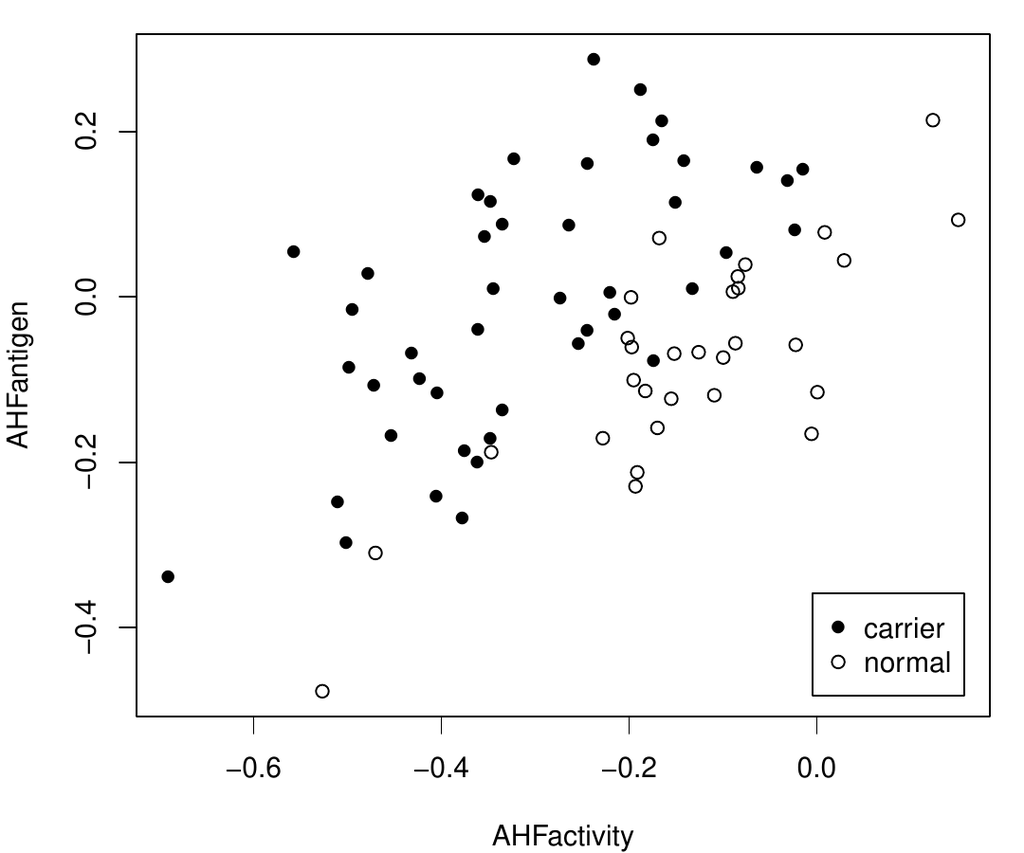

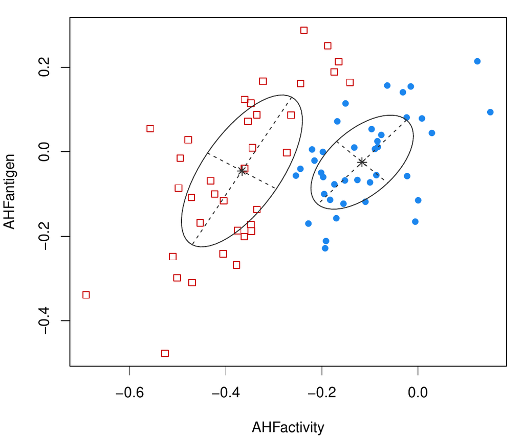

```r
> plot(mod, what = "classification", main = FALSE)
```

(a)

(b)

Figure 8: True class membership (a) and estimated classification using GMM (b) for the `hemophilia` dataset.

Bootstrap inference for GMMs is available through the function `MclustBootstrap()`, which requires the user to input an object returned by a call to `Mclust()`. Optionally, the user can also provide the number of bootstrap resamples `nboot` and the `type` of bootstrap to perform. By default, `nboot = 999` and `type = "bs"` for the nonparametric bootstrap. Thus, a simple call for computing the bootstrap distribution of the GMM parameters is the following:

```r
> boot <- MclustBootstrap(mod, nboot = 999, type = "bs")
```

Note that for the sake of clarity we have included the arguments `nboot` and `type`, but they can be omitted since they are set at their defaults.

The function `MclustBootstrap()` returns an object which can be plotted or summarised. For instance, to graph the bootstrap distribution for the mixing proportions and for the component means we may use the code:

```r
> par(mfrow = c(1,2))
> plot(boot, what = "pro")
> par(mfrow = c(2,2))
> plot(boot, what = "mean")
> par(mfrow = c(1,1))
```

The resulting plots are shown, respectively, in Figures 9 and 10.

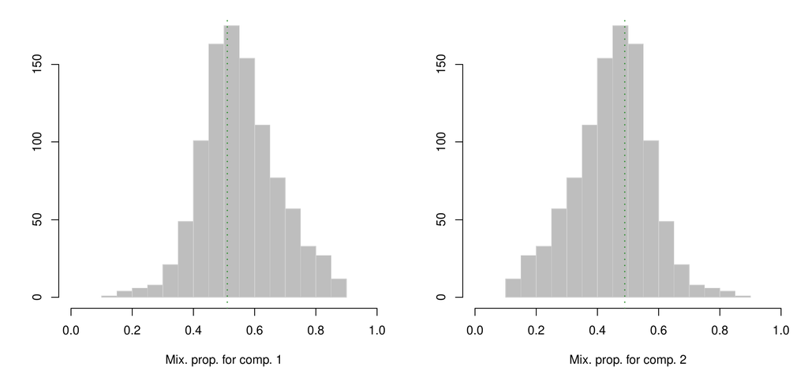

Figure 9: Bootstrap distribution for the mixture proportions. The vertical dotted lines refer to the MLEs for the GMM fitted to the `hemophilia` data.

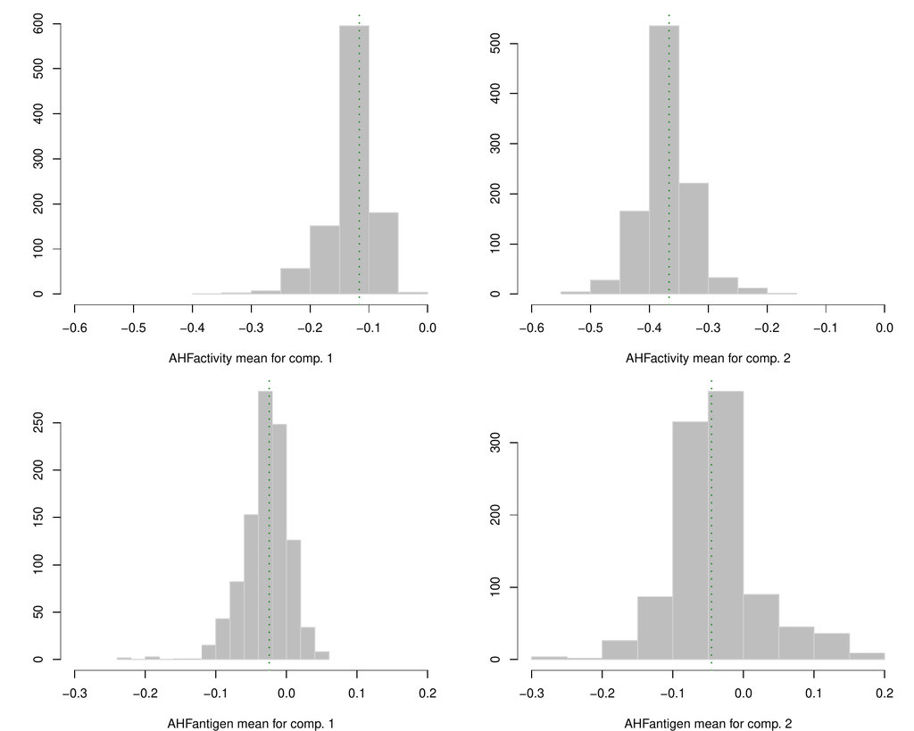

Figure 10: Bootstrap distribution for the mixture component means. The vertical dotted lines refer to the MLEs for the GMM fitted to the `hemophilia` data.

A numerical summary of the bootstrap procedure is available through the `summary` method, which by default returns the standard errors of GMM parameters:

```r
> summary(boot, what = "se")
----------------------------------------------------------
Resampling standard errors
----------------------------------------------------------
Model                      = VVV
Num. of mixture components = 2
Replications               = 999
Type                       = nonparametric bootstrap

Mixing probabilities:
        1         2
0.1249357 0.1249357

Means:
                     1          2
AHFactivity 0.04028375 0.04137370
AHFantigen  0.03262182 0.06456482

Variances:
[,,1]
            AHFactivity  AHFantigen
AHFactivity 0.007018580 0.004690481
AHFantigen  0.004690481 0.003155312
[,,2]
            AHFactivity  AHFantigen
AHFactivity 0.005757398 0.005897374
AHFantigen  0.005897374 0.009654623
```

The `summary` method can also return bootstrap percentile confidence intervals. For the generic GMM parameter $\psi$ of $\mathbf{\Psi}$, the percentile method yields the intervals $[\psi^*_{\alpha/2}, \psi^*_{1-\alpha/2}]$, where $\psi^*_q$ is the $q$th quantile (or the 100$q$th percentile) of the bootstrap distribution $(\widehat{\psi}^*_1, \ldots, \widehat{\psi}^*_B)$. These can be obtained by specifying in the `summary` call the argument `what = "ci"` and, optionally, the confidence level of the intervals (by default, `conf.level = 0.95`). For instance:

```r
> summary(boot, what = "ci")
----------------------------------------------------------
Resampling confidence intervals
----------------------------------------------------------
Model                      = VVV
Num. of mixture components = 2
Replications               = 999
Type                       = nonparametric bootstrap
Confidence level           = 0.95

Mixing probabilities:
              1         2
2.5%  0.3193742 0.1785054
97.5% 0.8214946 0.6806258

Means:
[,,1]
      AHFactivity  AHFantigen
2.5%  -0.22915526 -0.09784996
97.5% -0.07315876  0.02481681
[,,2]
      AHFactivity AHFantigen
2.5%   -0.4573113 -0.1571624
97.5%  -0.2747451  0.1318332

Variances:
[,,1]
      AHFactivity  AHFantigen
2.5%  0.004743597 0.007012672
97.5% 0.032144767 0.019245540
[,,2]
      AHFactivity  AHFantigen
2.5%  0.003981163 0.006049076
97.5% 0.027297495 0.045854646
```

The function `MclustBootstrap()` has also the provision for using the weighted likelihood bootstrap (Newton and Raftery 1994). This is a generalisation of the nonparametric bootstrap which assigns random (positive) weights to sample observations; it can be viewed as a generalized Bayesian bootstrap. The weights are obtained from a uniform Dirichlet distribution, i.e. by sampling from $n$ independent standard exponential distributions and then rescaling by their average. Then, the function `me.weighted()` in *mclust* allows one to apply a weighted EM algorithm. This approach may yield benefits when one or more components have small mixture proportions. In that case, a nonparametric bootstrap sample may have no representatives of them, but the weighted likelihood bootstrap will always have representatives of all groups.

In our data example the weighted likelihood bootstrap can be easily obtained by specifying `type = "wlbs"` in the `MclustBootstrap()` function call:

```r
> wlboot <- MclustBootstrap(mod, nboot = 999, type = "wlbs")
> summary(wlboot, what = "se")
----------------------------------------------------------
Resampling standard errors
----------------------------------------------------------
Model                      = VVV
Num. of mixture components = 2
Replications               = 999
Type                       = weighted likelihood bootstrap

Mixing probabilities:
        1         2
0.1323612 0.1323612

Means:
                     1          2
AHFactivity 0.03977347 0.04192182
AHFantigen  0.02989056 0.06897928

Variances:
[,,1]
            AHFactivity  AHFantigen
AHFactivity 0.007074450 0.004686432
AHFantigen  0.004686432 0.003254011
[,,2]
            AHFactivity  AHFantigen
AHFactivity 0.005511614 0.005746981
AHFantigen  0.005746981 0.009883791
```

In this case the differences between the nonparametric and the weighted likelihood bootstrap are negligible. We can summarise the inference for the components means obtained under the two approaches with the following graphs of bootstrap percentile confidence intervals:

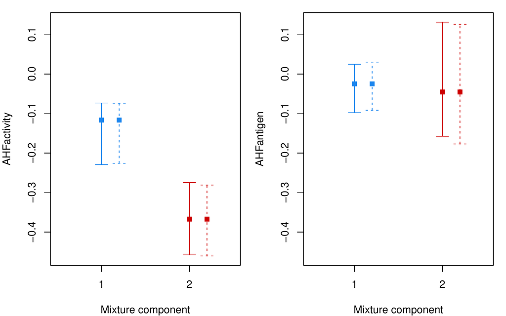

Figure 11: Bootstrap percentile intervals for the means of the GMM fitted to the `hemophilia` dataset. Solid lines refer to nonparametric bootstrap, dashed lines to the weighted likelihood bootstrap.

```r
> boot.ci <- summary(boot, what = "ci")
> wlboot.ci <- summary(wlboot, what = "ci")
> par(mfrow = c(1,2), mar = c(4,4,1,1))
> for(j in 1:mod$G)
     { plot(1:mod$G, mod$parameters$mean[j,], col = 1:mod$G, pch = 15,
           ylab = colnames(X)[j], xlab = "Mixture component",
           ylim = range(boot.ci$mean,wlboot.ci$mean),
           xlim = c(.5,mod$G+.5), xaxt = "n")
      points(1:mod$G+0.2, mod$parameters$mean[j,], col = 1:mod$G, pch = 15)
      axis(side = 1, at = 1:mod$G)
      with(boot.ci, errorBars(1:G, mean[1,j,], mean[2,j,], col = 1:G))
      with(wlboot.ci, errorBars(1:G+0.2, mean[1,j,], mean[2,j,], col = 1:G, lty = 2))
  }
> par(mfrow = c(1,1))
```

# Initialisation of the EM algorithm

The EM algorithm is an easy to implement and numerically stable algorithm which has reliable global convergence under fairly general conditions. However, the likelihood surface in mixture models tends to have multiple modes and thus initialisation of EM is crucial because it usually produces sensible results when started from reasonable starting values (Wu 1983).

In *mclust* the EM algorithm is initialised using the partitions obtained from model-based hierarchical agglomerative clustering (MBHAC). In this approach, hierarchical clusters are obtained by recursively merging the two clusters that provide the smallest decrease in the classification likelihood for Gaussian mixture model (Banfield and Raftery 1993). Efficient numerical algorithms have been discussed by Fraley (1998). Using MBHAC is particularly convenient because the underlying probabilistic model is shared by both the initialisation step and the model fitting step. Furthermore, MBHAC is also computationally advantageous because a single run provides the basis for initialising the EM algorithm for any number of mixture components and component-covariances parameterisations. Although there is no guarantee that the EM initialized by MBHAC will converge to the global optimum, it often provides reasonable starting points.

A problem with the MBHAC approach may arise in the presence of coarse data, resulting from the discrete nature of the data or from continuous data that are rounded when measured. In this case, ties must be broken by choosing the pair of entities that will be merged. This is often done at random, but regardless of which method is adopted for breaking ties, this choice can have important consequences because it changes the clustering of the remaining observations. Moreover, the final EM solution may depend on the ordering of the variables.

```r
> data(flea, package = "tourr")
> X <- data.matrix(flea[,1:6])
> Class <- factor(flea$species, labels = c("Concinna","Heikertingeri","Heptapotamica"))
> table(Class)
Class
     Concinna Heikertingeri Heptapotamica
           21            31            22
> col <- mclust.options("classPlotColors")[1:3]
> clp <- clPairs(X, Class, lower.panel = NULL, gap = 0,
                 symbols = c(16,15,17), colors = adjustcolor(col, alpha.f = 0.5))
> clPairsLegend(x = 0.1, y = 0.3, class = clp$class, col = col, pch = clp$pch,
              title = "Flea beatle species")
```

As can be seen from Figure 12, the observed values are rounded (to the nearest integer presumably) and there is a strong overplotting of points.

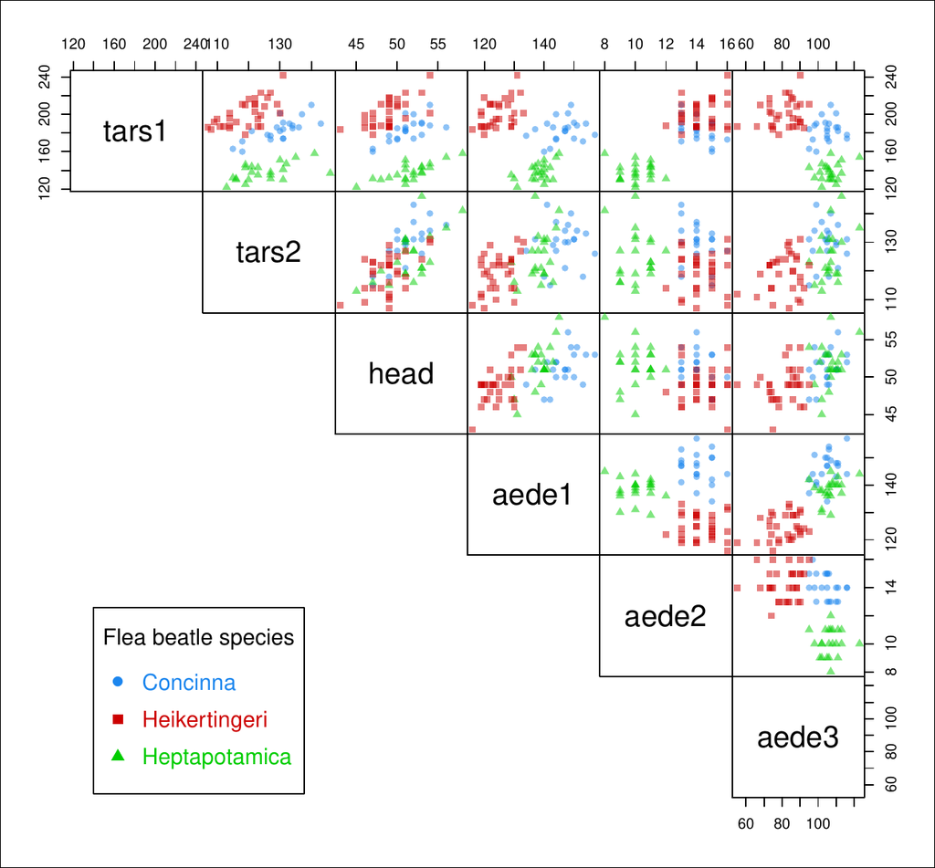

Figure 12: Scatterplot matrix for the Flea beetles data with points marked according to the true classes.

```r
> mod1 <- Mclust(X)
> summary(mod1)
----------------------------------------------------
Gaussian finite mixture model fitted by EM algorithm
----------------------------------------------------

Mclust EEE (ellipsoidal, equal volume, shape and orientation) model with 5 components:

 log.likelihood  n df       BIC       ICL
      -1292.308 74 55 -2821.339 -2825.769

Clustering table:
 1  2  3  4  5
21  2 20 20 11
> adjustedRandIndex(Class, mod1$classification)
[1] 0.7675713
```

```r
> mod2 <- Mclust(X[,6:1])
> summary(mod2)
----------------------------------------------------
Gaussian finite mixture model fitted by EM algorithm
----------------------------------------------------

Mclust EEE (ellipsoidal, equal volume, shape and orientation) model with 5 components:

 log.likelihood  n df       BIC       ICL
      -1287.027 74 55 -2810.777 -2812.702

Clustering table:
 1  2  3  4  5
22 21 22  7  2
> adjustedRandIndex(Class, mod2$classification)
[1] 0.8131206
```

By reversing the order of the variables in the fit of `mod2`, the initial partitions differ due to ties in the data, so the EM algorithm converges to different solutions of the same EEE model with 5 components. The second solution has a higher BIC and better accuracy.

In situations like this we may want to assess the stability of results by randomly starting the EM algorithm. The function `randomPairs()` may be called to obtain a random hierarchical structure suitable to be used as initial clustering partition:

```r
> mod3 <- Mclust(X, initialization = list(hcPairs = randomPairs(X, seed = 123)))
> summary(mod3)
----------------------------------------------------
Gaussian finite mixture model fitted by EM algorithm
----------------------------------------------------

Mclust EEE (ellipsoidal, equal volume, shape and orientation) model with 4 components:

 log.likelihood  n df       BIC       ICL
      -1298.211 74 48 -2803.017 -2807.713

Clustering table:
 1  2  3  4
16 15 22 21
> adjustedRandIndex(Class, mod3$classification)
[1] 0.7867056
```

Using a random start we obtain a EEE model with 4 components, which has a higher BIC but a lower ARI. However, a better initialisation may be found using the approach discussed in L. Scrucca and Raftery (2015). The main idea is to project the data through a suitable transformation which enhances separation among clusters before applying the MBHAC at the initialisation step. Once a reasonable hierarchical partition is obtained, the EM algorithm is run using the data on the original scale. For instance, a GMM started using the scaled SVD transformation is obtained with the following code:

```r
> mod4 <- Mclust(X, initialization = list(hcPairs = hc(X, use = "SVD")))
> summary(mod4)
----------------------------------------------------
Gaussian finite mixture model fitted by EM algorithm
----------------------------------------------------

Mclust EEE (ellipsoidal, equal volume, shape and orientation) model with 3 components:

 log.likelihood  n df       BIC       ICL
      -1304.552 74 41 -2785.572 -2785.574

Clustering table:
 1  2  3
21 31 22
> adjustedRandIndex(Class, mod4$classification)
[1] 1
```

In this case we achieve both the highest BIC and a perfect classification of the fleas into the actual species.

We conclude by noting that in the case of large datasets, i.e. having a large number of observations or cases, a subsample of the data can be used in the MBHAC phase before applying the EM algorithm to the full data set. This is easily done by providing an optional argument to `Mclust()` or `mclustBIC()` (as well as many other functions) as a vector, say `s`, of logical values or numerical indices specifying the subset of data to be used in the initial hierarchical clustering phase:

```r
> Mclust(X, initialization = list(subset = s))
```

# Density estimation

Density estimation plays an important role in applied statistical data analysis and theoretical research. Finite mixture models provide a flexible semi-parametric model-based approach to density estimation, which makes it possible to accurately approximate any given probability distribution. *mclust* provides a simple interface to Gaussian mixture models for univariate and multivariate density estimation.

Alan J. Izenman and Sommer (1988) considered the fitting of a Gaussian mixture to the distribution of the thickness of stamps in the 1872 Hidalgo stamp issue of Mexico [^2]. A density estimate based on GMM can be obtained using the function `densityMclust()`:

```r
> data(Hidalgo1872, package = "MMST")
> Thickness <- Hidalgo1872$thickness
> Year <- rep(c("1872", "1873-74"), c(289, 196))
> dens <- densityMclust(Thickness)
> summary(dens$BIC)
Best BIC values:
              V,3         V,5        V,4
BIC      2983.791 2974.939223 2972.19349
BIC diff    0.000   -8.852019  -11.59775
> summary(dens, parameters = TRUE)
-------------------------------------------------------
Density estimation via Gaussian finite mixture modeling
-------------------------------------------------------

Mclust V (univariate, unequal variance) model with 3 components:

 log.likelihood   n df      BIC      ICL
       1516.632 485  8 2983.791 2890.914

Clustering table:
  1   2   3
128 171 186

Mixing probabilities:
        1         2         3
0.2661410 0.3011217 0.4327374

Means:
         1          2          3
0.07215458 0.07935341 0.09919740

Variances:
             1              2              3
0.000004814927 0.000003097694 0.000188461484
```

The model selected is a three-component mixture with different variances. A graph of the density estimated is shown in Figure13a and is obtained with the code:

```r
> br <- seq(min(Thickness), max(Thickness), length = 21)
> plot(dens, what = "density", data = Thickness, breaks = br)
```

Here a histogram of the observed data is also drawn by providing the optional argument `data` and with breakpoints between histogram cells specified in the argument `breaks`. From the graph, three modes appear at the means of the mixture components: one with larger stamp thickness, and two corresponding to thinner stamps.

Additional information can also be used. In particular, thickness measurements can be grouped according to the year of consignment; the first 289 stamps refer to the 1872 issue, and the remaining 196 stamps to the years 1873–1874. We may draw a (suitable scaled) histogram for each year-of-consignment and then add the estimated components densities as follows:

```r
> h1 <- hist(Thickness[Year == "1872"], breaks = br, plot = FALSE)
> h1$density <- h1$density*prop.table(table(Year))[1]
> h2 <- hist(Thickness[Year == "1873-74"], breaks = br, plot = FALSE)
> h2$density <- h2$density*prop.table(table(Year))[2]
> x <- seq(min(Thickness)-diff(range(Thickness))/10,
           max(Thickness)+diff(range(Thickness))/10, length = 200)
> cdens <- predict(dens, x, what = "cdens")
> cdens <- t(apply(cdens, 1, function(d) d*dens$parameters$pro))
> col <- adjustcolor(mclust.options("classPlotColors")[1:2], alpha = 0.3)
> plot(h1, xlab = "Thickness", freq = FALSE, main = "", border = FALSE, col = col[1],
       xlim = range(x), ylim = range(h1$density, h2$density, cdens))
> plot(h2, add = TRUE, freq = FALSE, border = FALSE, col = col[2])
> matplot(x, cdens, type = "l", lwd = 1, add = TRUE, lty = 1:3, col = 1)
> box()
```

The result is shown in Figure 13b. Stamps from 1872 show a two-regime distribution, with one corresponding to the component with the largest thickness, and one whose distribution essentially overlaps with the bimodal distribution of stamps for the years 1873–1874.

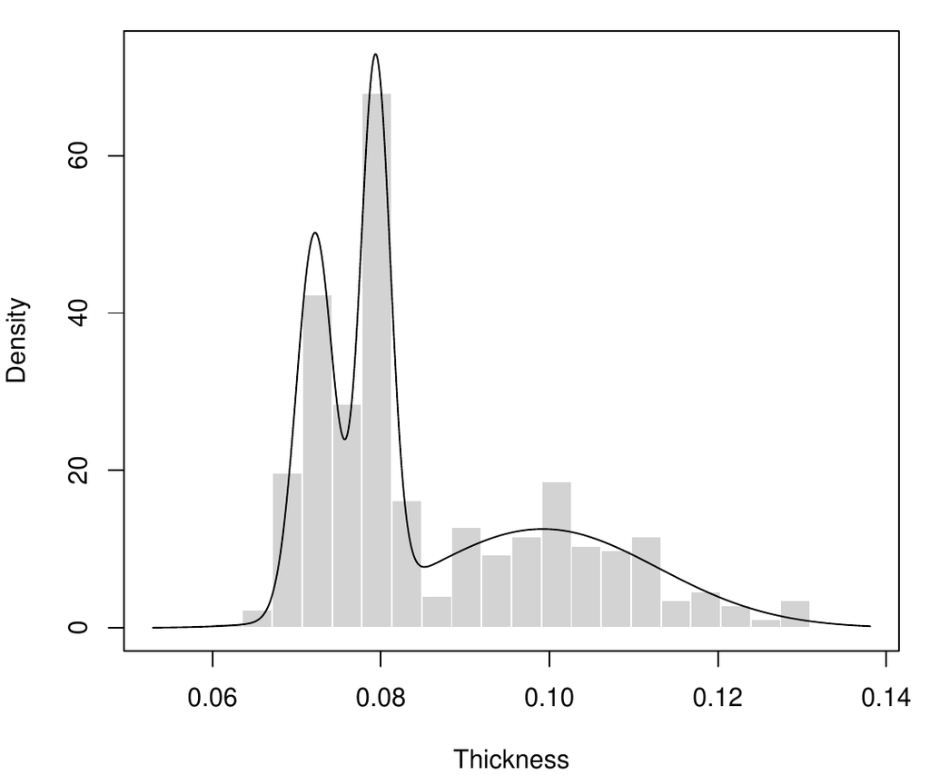

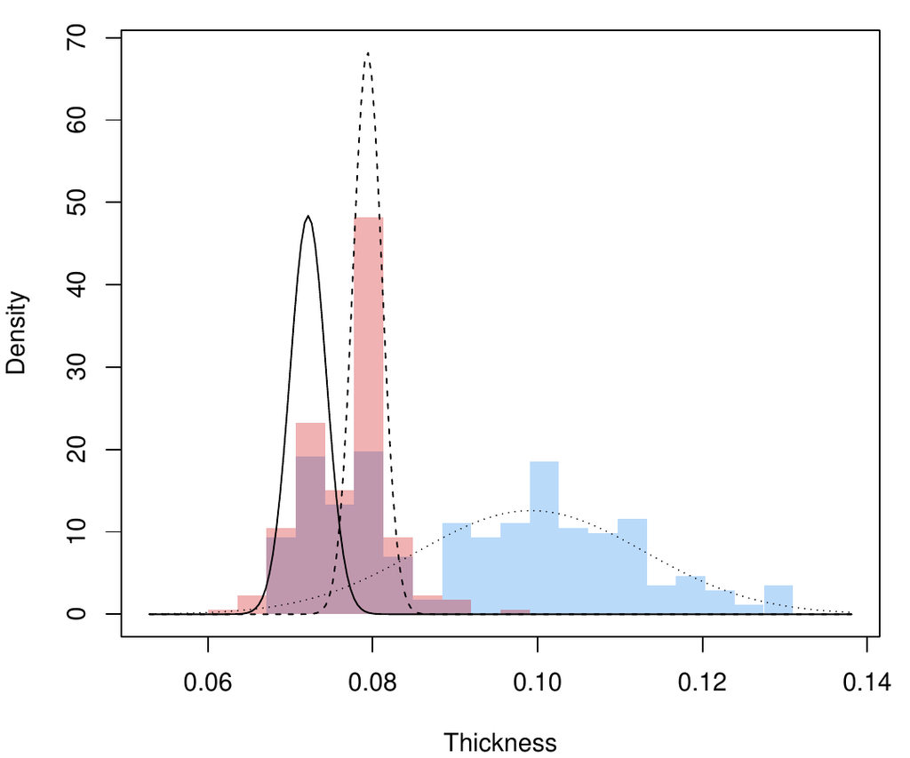

(a)

(b)

Figure 13: (a) Histogram with mixture-based density estimate curve, and (b) histograms by group-year with estimated mixture-component densities, for the `Hidalgo1872` stamps dataset.

As an example of bivariate density estimation, consider the well-known ‘Old Faithful’ data set which provides the waiting time between eruptions (`waiting`) and the duration of the eruptions (`eruptions`) for the Old Faithful geyser in Yellowstone National Park, Wyoming, USA. The dataset can be read and data plotted as follows:

```r
> data(faithful)
> plot(faithful, cex = 0.5)
```

A bivariate density estimate for the Faithful data is obtained with the commands:

```r
> dens <- densityMclust(faithful)
> summary(dens)
-------------------------------------------------------
Density estimation via Gaussian finite mixture modeling
-------------------------------------------------------

Mclust EEE (ellipsoidal, equal volume, shape and orientation) model with 3 components:

 log.likelihood   n df       BIC       ICL
      -1126.361 272 11 -2314.386 -2360.865

Clustering table:
  1   2   3
130  97  45
```

Model selection based on the BIC selects a three-component mixture with common covariance matrix (EEE). One component is used to model the group of observations having both low duration and low waiting times, whereas two components are needed to approximate the skewed distribution of the observations with larger duration and waiting times.

Figure 14b-d shows some of the available graphs in *mclust* for a bivariate density estimated by GMM. These can be obtained with the commands:

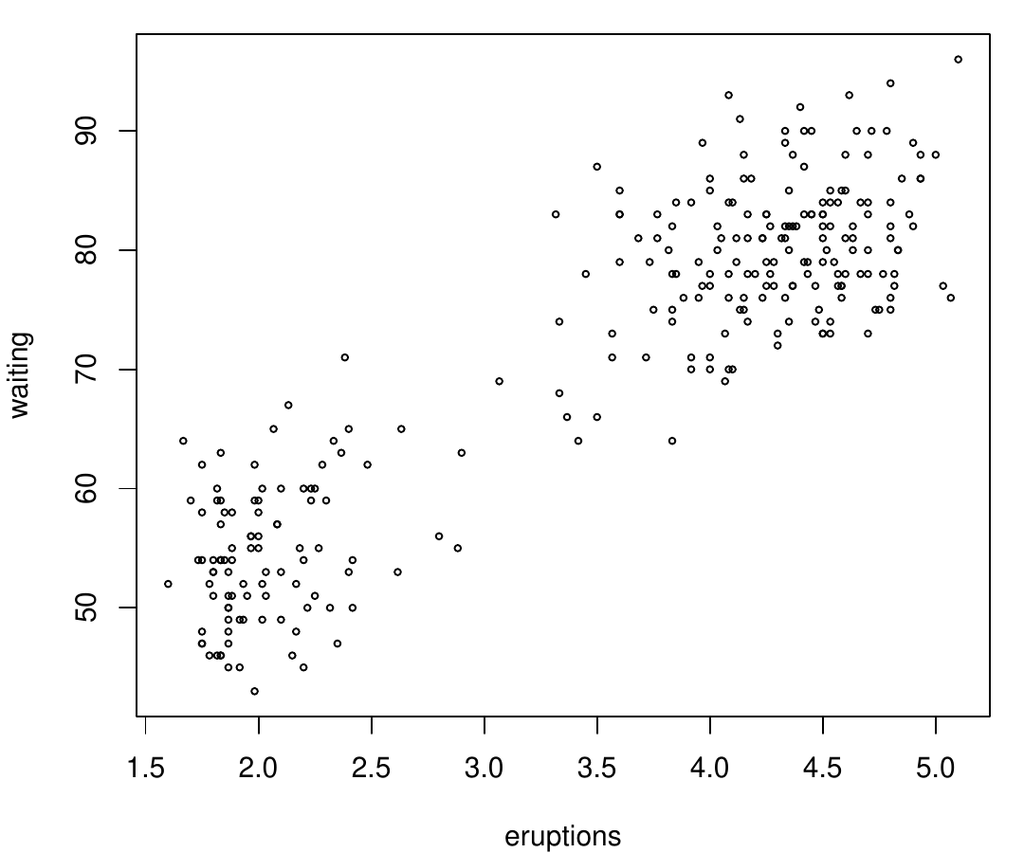

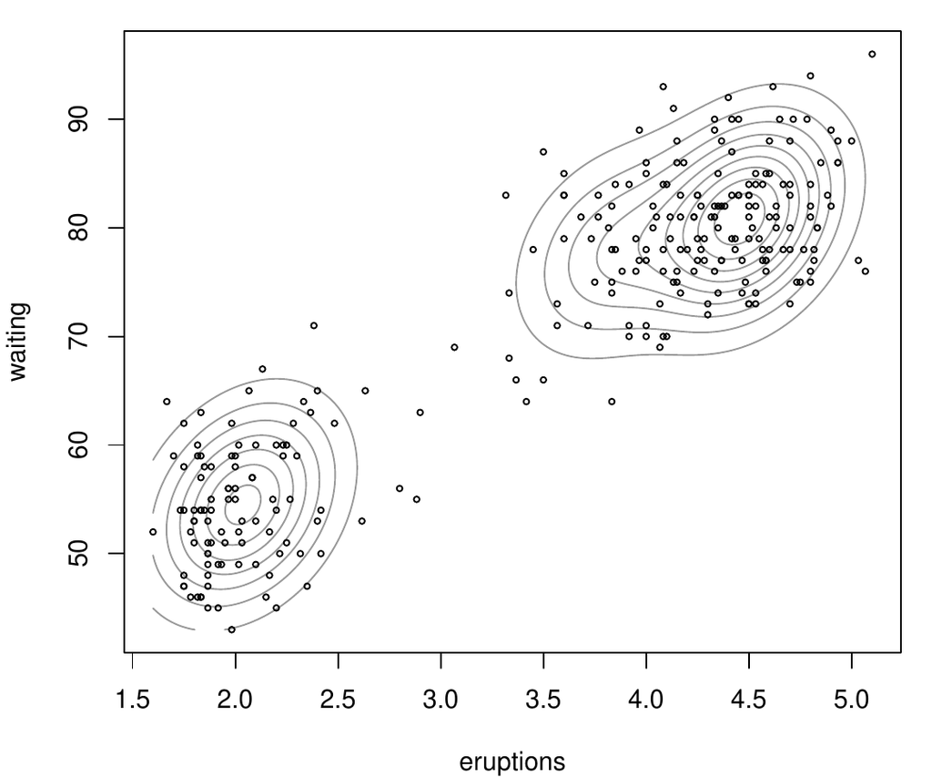

```r
> plot(dens, what = "density", data = faithful, grid = 200, points.cex = 0.5,
       drawlabels = FALSE)
> plot(dens, what = "density", type = "image", col = "steelblue", grid = 200)
> plot(dens, what = "density", type = "persp", theta = -25, phi = 20,
       border = adjustcolor(grey(0.1), alpha.f = 0.3))
```

(a)

(b)

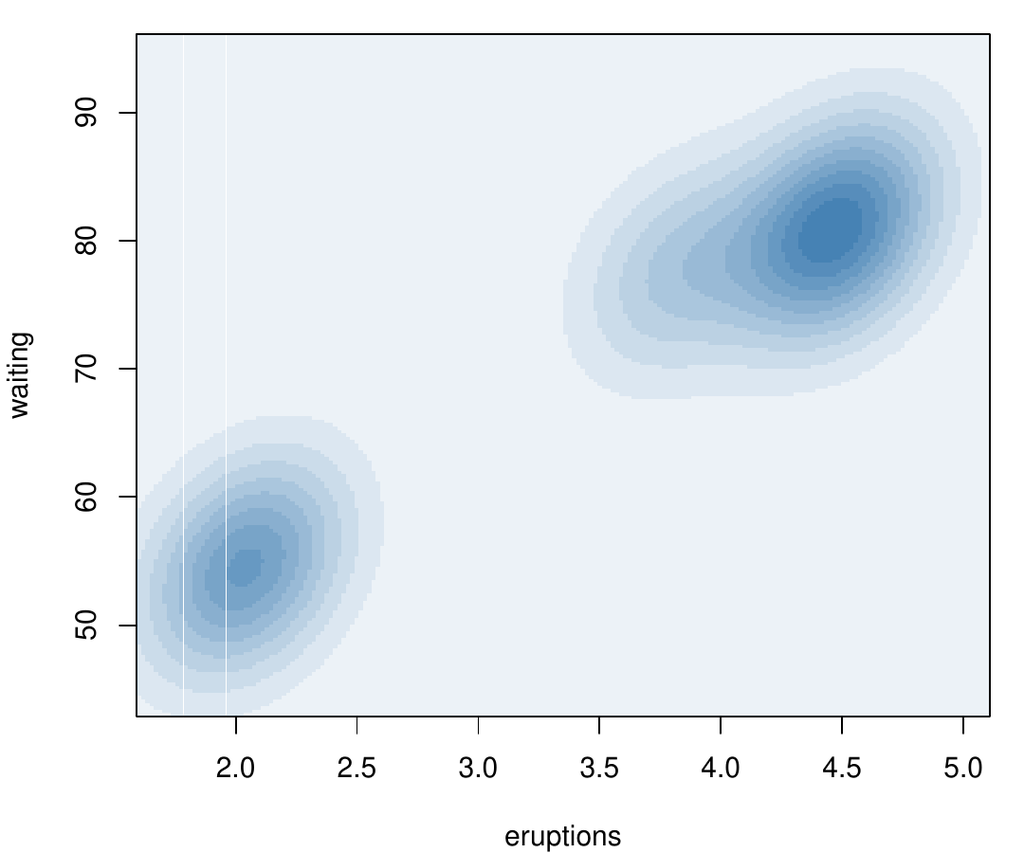

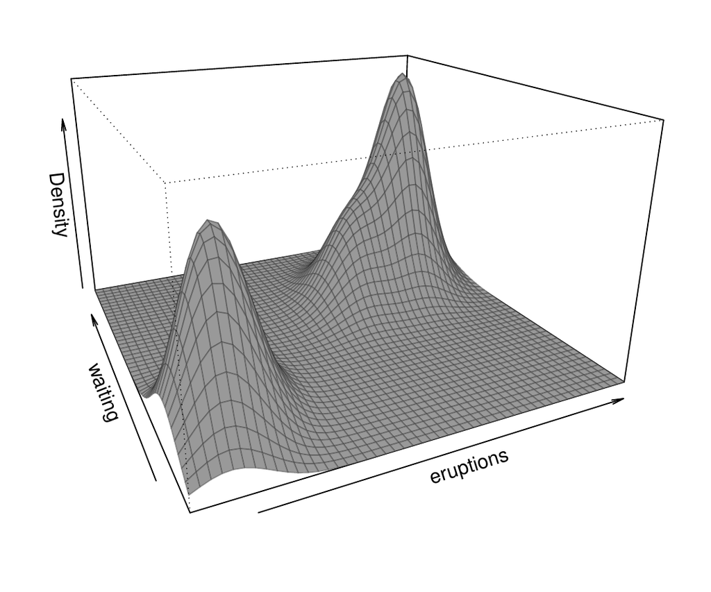

(c)

(d)

Figure 14: Plot of the Old Faithful data (a), mixture-based density estimate contours (b), image plot of density estimate (c) and perspective plot of the bivariate density estimate (d).